# Joining Data With Dplyr - Data Camp

Edneide Ramalho

28 Março, 2021

# 1 The inner_join verb

## 1.1 Base de dados

- Vamos trabalhar com a base de dados LEGO.
- Lembre de definir o diretório de trabalho. Sempre defino o diretório de trabalho na pasta em que está o arquivo .R.

```r
# Bibliotecas
library(dplyr)
library(readr)
```

```r
sets <- read_csv("dados/sets.csv")
glimpse(sets)
```

```
## Rows: 11,673
## Columns: 5
## $ set_num   <chr> "00-1", "0011-2", "0011-3", "0012-1", "0013-1", "0014-1", "0…
## $ name      <chr> "Weetabix Castle", "Town Mini-Figures", "Castle 2 for 1 Bonu…
## $ year      <dbl> 1970, 1978, 1987, 1979, 1979, 1979, 1979, 1978, 1976, 1976, …
## $ theme_id  <dbl> 414, 84, 199, 143, 143, 143, 143, 186, 413, 413, 413, 366, 6…
## $ num_parts <dbl> 471, 12, 2, 12, 12, 12, 18, 15, 147, 149, 126, 35, 3, 3, 57,…
```

```r
head(sets)
```

```
## # A tibble: 6 x 5
##   set_num name                        year theme_id num_parts
##   <chr>   <chr>                      <dbl>    <dbl>     <dbl>
## 1 00-1    Weetabix Castle             1970      414       471
## 2 0011-2  Town Mini-Figures           1978       84        12
## 3 0011-3  Castle 2 for 1 Bonus Offer  1987      199         2
## 4 0012-1  Space Mini-Figures          1979      143        12
## 5 0013-1  Space Mini-Figures          1979      143        12
## 6 0014-1  Space Mini-Figures          1979      143        12
```

- Há uma outra base de dados chamada `themes`.
- A variável `theme_id` (da base de dados `set`) faz o link com a variável `id` da base de dados `themes.`

```r
themes <- read_csv("dados/themes.csv")
head(themes)
```

```
## # A tibble: 6 x 3
##      id name           parent_id
##   <dbl> <chr>              <dbl>
## 1     1 Technic               NA
## 2     2 Arctic Technic         1
## 3     3 Competition            1
## 4     4 Expert Builder         1
## 5     5 Model                  1
## 6     6 Airport                5
```

## 1.2 Inner join

- O argumento `by` “diz” ao verbo `inner_join` como as bases devem ser colocadas juntas.

```r
joining_df <- sets %>%
  inner_join(themes, by = c("theme_id" = "id"))
head(joining_df)
```

```
## # A tibble: 6 x 7
##   set_num name.x                   year theme_id num_parts name.y      parent_id
##   <chr>   <chr>                   <dbl>    <dbl>     <dbl> <chr>           <dbl>
## 1 00-1    Weetabix Castle          1970      414       471 Castle            411
## 2 0011-2  Town Mini-Figures        1978       84        12 Supplement…        67
## 3 0011-3  Castle 2 for 1 Bonus O…  1987      199         2 Lion Knigh…       186
## 4 0012-1  Space Mini-Figures       1979      143        12 Supplement…       126
## 5 0013-1  Space Mini-Figures       1979      143        12 Supplement…       126
## 6 0014-1  Space Mini-Figures       1979      143        12 Supplement…       126
```

```r
names(joining_df)
```

```
## [1] "set_num"   "name.x"    "year"      "theme_id"  "num_parts" "name.y"
## [7] "parent_id"
```

- Note que temos duas variável `name`:
  - `name.x` para a primeira data frame, e
  - `name.y` para a segunda.
- Isso ocorre porque não se poder ter duas variáveis com o mesmo nome.

## 1.3 Customizing your join

- Para deixar os nomes das variáveis compartilhas mais claros, podemos adicionar um argumento à função `inner_join` :

```r
joining_df2 <- sets %>%
  inner_join(themes,
             by = c("theme_id" = "id"),
             suffix = c("_set", "_theme"))
head(joining_df2)
```

```
## # A tibble: 6 x 7
##   set_num name_set                 year theme_id num_parts name_theme  parent_id
##   <chr>   <chr>                   <dbl>    <dbl>     <dbl> <chr>           <dbl>
## 1 00-1    Weetabix Castle          1970      414       471 Castle            411
## 2 0011-2  Town Mini-Figures        1978       84        12 Supplement…        67
## 3 0011-3  Castle 2 for 1 Bonus O…  1987      199         2 Lion Knigh…       186
## 4 0012-1  Space Mini-Figures       1979      143        12 Supplement…       126
## 5 0013-1  Space Mini-Figures       1979      143        12 Supplement…       126
## 6 0014-1  Space Mini-Figures       1979      143        12 Supplement…       126
```

## 1.4 Most common themes

```r
joining_df2 %>%
  dplyr::count(name_theme, sort = TRUE)
```

```
## # A tibble: 386 x 2
##    name_theme        n
##    <chr>         <int>
##  1 Supplemental    496
##  2 Technic         435
##  3 City            287
##  4 Friends         269
##  5 Basic Set       257
##  6 Creator         249
##  7 Gear            246
##  8 Service Packs   242
##  9 Duplo           219
## 10 Star Wars       211
## # … with 376 more rows
```

## 1.5 Exercícios

### 1.5.1 **What columns would you join on?**

You’ll be joining together the `parts` and `part_categories` tables. You can first inspect them in the console. To join these two tables together using the `inner_join` verb, what columns would you join from each table?

```r
# Carregando os dados
parts <- read_csv("dados/parts.csv")
part_categories <- read_csv("dados/part_categories.csv")
```

```r
parts %>%
  inner_join(part_categories,
             by = c("part_cat_id" = "id"),
             suffix = c("_part", "_category"))
```

```
## # A tibble: 25,993 x 4
##    part_num   name_part                                part_cat_id name_category
##    <chr>      <chr>                                          <dbl> <chr>
##  1 0687b1     Set 0687 Activity Booklet 1                       17 Non-LEGO
##  2 0901       Baseplate 16 x 30 with Set 080 Yellow H…           1 Baseplates
##  3 0902       Baseplate 16 x 24 with Set 080 Small Wh…           1 Baseplates
##  4 0903       Baseplate 16 x 24 with Set 080 Red Hous…           1 Baseplates
##  5 0904       Baseplate 16 x 24 with Set 080 Large Wh…           1 Baseplates
##  6 1          Homemaker Bookcase 2 x 4 x 4                       7 Containers
##  7 10         Baseplate 24 x 32                                  1 Baseplates
##  8 10016414   Sticker Sheet #1 for 41055-1                      17 Non-LEGO
##  9 10019stk01 Sticker for Set 10019 - (43274/4170393)           17 Non-LEGO
## 10 10026stk01 Sticker for Set 10026 - (44942/4184185)           17 Non-LEGO
## # … with 25,983 more rows
```

## 1.6 Joining with a one-to-many relationship

- **The** `inventories` **table:**

```r
library(readr)
inventories <- read_csv("dados/inventories.csv")
glimpse(inventories)
```

```
## Rows: 11,681
## Columns: 3
## $ id      <dbl> 1, 3, 4, 15, 16, 17, 19, 21, 22, 25, 26, 27, 28, 29, 30, 31, 3…
## $ version <dbl> 1, 1, 1, 1, 1, 1, 1, 1, 1, 1, 1, 1, 1, 1, 1, 1, 1, 1, 1, 1, 1,…
## $ set_num <chr> "7922-1", "3931-1", "6942-1", "5158-1", "903-1", "850950-1", "…
```

- Quando a coluna que queremos juntar tem o mesmo nome, o `by` recebe somente este nome:

```r
sets_plus_inventories <- sets %>%
  inner_join(inventories, by = "set_num")
dim(sets_plus_inventories)
```

```
## [1] 11681     7
```

- A tabela resultante do `join`, tem mais linhas, porque cada elemento tem várias versões:
- Filtrando para a versão 1:

```r
sets_plus_inventories %>%
  dplyr::filter(version == 1)
```

```
## # A tibble: 11,669 x 7
##    set_num name                          year theme_id num_parts    id version
##    <chr>   <chr>                        <dbl>    <dbl>     <dbl> <dbl>   <dbl>
##  1 00-1    Weetabix Castle               1970      414       471  5574       1
##  2 0011-2  Town Mini-Figures             1978       84        12  5087       1
##  3 0011-3  Castle 2 for 1 Bonus Offer    1987      199         2  2216       1
##  4 0012-1  Space Mini-Figures            1979      143        12  1414       1
##  5 0013-1  Space Mini-Figures            1979      143        12  4609       1
##  6 0014-1  Space Mini-Figures            1979      143        12  5004       1
##  7 0015-1  Space Mini-Figures            1979      143        18 12208       1
##  8 0016-1  Castle Mini Figures           1978      186        15 13351       1
##  9 00-2    Weetabix Promotional House 1  1976      413       147 13813       1
## 10 00-3    Weetabix Promotional House 2  1976      413       149   898       1
## # … with 11,659 more rows
```

## 1.7 Exercises

### 1.7.1 **Joining parts and inventories**

The LEGO data has many tables that can be joined together. Often times, some of the things you care about may be a few tables away (we’ll get to that later in the course). For now, we know that `parts` is a list of all LEGO parts, and a new table, `inventory_parts`, has some additional information about those parts, such as the `color_id` of each part you would find in a specific LEGO kit.

Let’s join these two tables together to observe how joining `parts` with `inventory_parts` increases the size of your table because of the one-to-many relationship that exists between these two tables.

- Connect the `parts` and `inventory_parts` tables by their **part numbers** using an inner join.

```r
library(readr)
inventory_parts <- read_csv("dados/inventory_parts.csv")
# Combine the parts and inventory_parts tables
parts %>%
    inner_join(inventory_parts, by = "part_num")
```

```
## # A tibble: 580,069 x 7
##    part_num name             part_cat_id inventory_id color_id quantity is_spare
##    <chr>    <chr>                  <dbl>        <dbl>    <dbl>    <dbl> <lgl>
##  1 0687b1   Set 0687 Activi…          17        15235     9999        1 FALSE
##  2 0901     Baseplate 16 x …           1         1973        2        1 FALSE
##  3 0902     Baseplate 16 x …           1         1973        2        1 FALSE
##  4 0903     Baseplate 16 x …           1         1973        2        1 FALSE
##  5 0904     Baseplate 16 x …           1         1973        2        1 FALSE
##  6 1        Homemaker Bookc…           7          508       15        1 FALSE
##  7 1        Homemaker Bookc…           7         1158       15        2 FALSE
##  8 1        Homemaker Bookc…           7         2137        4        3 FALSE
##  9 1        Homemaker Bookc…           7         2179       15        3 FALSE
## 10 1        Homemaker Bookc…           7         2257       14        3 FALSE
## # … with 580,059 more rows
```

### 1.7.2 **Joining in either direction**

An `inner_join` works the same way with either table in either position. The table that is specified first is arbitrary, since you will end up with the same information in the resulting table either way.

Let’s prove this by joining the same two tables from the last exercise in the opposite order!

- Connect the `inventory_parts` table with the `parts` tables.

```r
inventory_parts %>%
  inner_join(parts, by = "part_num")
```

```
## # A tibble: 580,069 x 7
##    inventory_id part_num  color_id quantity is_spare name            part_cat_id
##           <dbl> <chr>        <dbl>    <dbl> <lgl>    <chr>                 <dbl>
##  1            1 48379c01        72        1 FALSE    Sports Promo F…          27
##  2            1 48395            7        1 FALSE    Sports Promo S…          27
##  3            1 mcsport6        25        1 FALSE    Sports Promo F…          13
##  4            1 paddle           0        1 FALSE    Sports Promo P…          27
##  5            3 11816pr0…       78        1 FALSE    Minifig Head M…          13
##  6            3 2343            47        1 FALSE    Minifig Goblet           27
##  7            3 3003            29        1 FALSE    Brick 2 x 2              11
##  8            3 30176            2        1 FALSE    Round 1 x 1 - …          28
##  9            3 3020            15        1 FALSE    Plate 2 x 4              14
## 10            3 3022            15        2 FALSE    Plate 2 x 2              14
## # … with 580,059 more rows
```

## 1.8 **Joining three or more tables**

- Você pode juntar quantas tabelas você quiser usando `inner_join` da mesma forma que você usa vários verbos do `dplyr`.

```r
sets_inv_themes <- sets %>%
  inner_join(inventories, by = "set_num") %>%
  inner_join(themes, by = c("theme_id" = "id"))
head(sets_inv_themes)
```

```
## # A tibble: 6 x 9
##   set_num name.x         year theme_id num_parts    id version name.y  parent_id
##   <chr>   <chr>         <dbl>    <dbl>     <dbl> <dbl>   <dbl> <chr>       <dbl>
## 1 00-1    Weetabix Cas…  1970      414       471  5574       1 Castle        411
## 2 0011-2  Town Mini-Fi…  1978       84        12  5087       1 Supple…        67
## 3 0011-3  Castle 2 for…  1987      199         2  2216       1 Lion K…       186
## 4 0012-1  Space Mini-F…  1979      143        12  1414       1 Supple…       126
## 5 0013-1  Space Mini-F…  1979      143        12  4609       1 Supple…       126
## 6 0014-1  Space Mini-F…  1979      143        12  5004       1 Supple…       126
```

- Veja que temos `name.x` e `name.y`, e podemos modificar isto usando o argumento `suffix`

```r
sets_inv_themes2 <- sets %>%
  inner_join(inventories, by = "set_num") %>%
  inner_join(themes, by = c("theme_id" = "id"),
             suffix = c("_set", "_theme"))
head(sets_inv_themes2)
```

```
## # A tibble: 6 x 9
##   set_num name_set    year theme_id num_parts    id version name_theme parent_id
##   <chr>   <chr>      <dbl>    <dbl>     <dbl> <dbl>   <dbl> <chr>          <dbl>
## 1 00-1    Weetabix …  1970      414       471  5574       1 Castle           411
## 2 0011-2  Town Mini…  1978       84        12  5087       1 Supplemen…        67
## 3 0011-3  Castle 2 …  1987      199         2  2216       1 Lion Knig…       186
## 4 0012-1  Space Min…  1979      143        12  1414       1 Supplemen…       126
## 5 0013-1  Space Min…  1979      143        12  4609       1 Supplemen…       126
## 6 0014-1  Space Min…  1979      143        12  5004       1 Supplemen…       126
```

- Agora os nomes estão modificados e sabemos de onde vem cada um deles.

## 1.9 Exercícios

### 1.9.1 **Joining three tables**

You can string together multiple joins with `inner_join` and the pipe (`%>%`), both with which you are already very familiar!

We’ll now connect `sets`, a table that tells us about each LEGO kit, with `inventories`, a table that tells us the specific version of a given set, and finally to `inventory_parts`, a table which tells us how many of each part is available in each LEGO kit.

So if you were building a Batman LEGO set, `sets` would tell you the name of the set, `inventories` would give you IDs for each of the versions of the set, and `inventory_parts` would tell you how many of each part would be in each version.

- Combine the `inventories` table with the `sets` table.
- Next, join the `inventory_parts` table to the table you created in the previous join by the inventory IDs.

```r
sets %>%
    # Add inventories using an inner join
    inner_join(inventories, by = "set_num") %>%
    # Add inventory_parts using an inner join
    inner_join(inventory_parts, by = c("id" = "inventory_id"))
```

```
## # A tibble: 580,251 x 11
##    set_num name          year theme_id num_parts    id version part_num color_id
##    <chr>   <chr>        <dbl>    <dbl>     <dbl> <dbl>   <dbl> <chr>       <dbl>
##  1 00-1    Weetabix Ca…  1970      414       471  5574       1 29c01           4
##  2 00-1    Weetabix Ca…  1970      414       471  5574       1 29c01          15
##  3 00-1    Weetabix Ca…  1970      414       471  5574       1 3001a          15
##  4 00-1    Weetabix Ca…  1970      414       471  5574       1 3001a           4
##  5 00-1    Weetabix Ca…  1970      414       471  5574       1 3001a           1
##  6 00-1    Weetabix Ca…  1970      414       471  5574       1 3002a           4
##  7 00-1    Weetabix Ca…  1970      414       471  5574       1 3002a          15
##  8 00-1    Weetabix Ca…  1970      414       471  5574       1 3003           15
##  9 00-1    Weetabix Ca…  1970      414       471  5574       1 3003            1
## 10 00-1    Weetabix Ca…  1970      414       471  5574       1 3003           14
## # … with 580,241 more rows, and 2 more variables: quantity <dbl>,
## #   is_spare <lgl>
```

### 1.9.2 What’s the common color?

Now let’s join an additional table, `colors`, which will tell us the color of each part in each set, so that we can answer the question, “what is the most common color of a LEGO piece?”

- Inner join the `colors` table using the `color_id` column from the previous join and the `id` column from `colors`; use the suffixes `"_set"` and `"_color"`.

```r
colors <- colors <- read_csv("dados/colors.csv")
# Count the number of colors and sort
sets %>%
    inner_join(inventories, by = "set_num") %>%
    inner_join(inventory_parts, by = c("id" = "inventory_id")) %>%
  inner_join(colors, by = c("color_id" = "id"), suffix = c("_set", "_color"))
```

```
## # A tibble: 580,251 x 14
##    set_num name_set      year theme_id num_parts    id version part_num color_id
##    <chr>   <chr>        <dbl>    <dbl>     <dbl> <dbl>   <dbl> <chr>       <dbl>
##  1 00-1    Weetabix Ca…  1970      414       471  5574       1 29c01           4
##  2 00-1    Weetabix Ca…  1970      414       471  5574       1 29c01          15
##  3 00-1    Weetabix Ca…  1970      414       471  5574       1 3001a          15
##  4 00-1    Weetabix Ca…  1970      414       471  5574       1 3001a           4
##  5 00-1    Weetabix Ca…  1970      414       471  5574       1 3001a           1
##  6 00-1    Weetabix Ca…  1970      414       471  5574       1 3002a           4
##  7 00-1    Weetabix Ca…  1970      414       471  5574       1 3002a          15
##  8 00-1    Weetabix Ca…  1970      414       471  5574       1 3003           15
##  9 00-1    Weetabix Ca…  1970      414       471  5574       1 3003            1
## 10 00-1    Weetabix Ca…  1970      414       471  5574       1 3003           14
## # … with 580,241 more rows, and 5 more variables: quantity <dbl>,
## #   is_spare <lgl>, name_color <chr>, rgb <chr>, is_trans <lgl>
```

- Count the `name_color` column and sort the results so the most prominent colors appear first.

```r
colors <- colors <- read_csv("dados/colors.csv")
# Count the number of colors and sort
sets %>%
    inner_join(inventories, by = "set_num") %>%
    inner_join(inventory_parts, by = c("id" = "inventory_id")) %>%
    inner_join(colors, by = c("color_id" = "id"), suffix = c("_set", "_color")) %>%
  count(name_color, sort = TRUE)
```

```
## # A tibble: 131 x 2
##    name_color             n
##    <chr>              <int>
##  1 Black             115176
##  2 White              66549
##  3 Light Bluish Gray  55317
##  4 Red                50217
##  5 Dark Bluish Gray   43913
##  6 Yellow             38837
##  7 Blue               29857
##  8 Light Gray         25339
##  9 Reddish Brown      14168
## 10 Tan                13681
## # … with 121 more rows
```

# 2 The left_join verb

## 2.1 Relembrando o inner_join

```r
inventory_parts_joined <- inventories %>%
  inner_join(inventory_parts, by = c("id" = "inventory_id")) %>%
  select(-id, -version) %>%
  arrange(desc(quantity))
inventory_parts_joined
```

```
## # A tibble: 580,251 x 5
##    set_num  part_num color_id quantity is_spare
##    <chr>    <chr>       <dbl>    <dbl> <lgl>
##  1 k34432-1 3024           15     1440 FALSE
##  2 k34433-1 3024           15     1170 FALSE
##  3 40179-1  3024           72      900 FALSE
##  4 40179-1  3024            0      900 FALSE
##  5 40179-1  3024           15      900 FALSE
##  6 40179-1  3024           14      900 FALSE
##  7 40179-1  3024           71      900 FALSE
##  8 k34434-1 3024           15      810 FALSE
##  9 21010-1  3023          320      771 FALSE
## 10 42055-1  2780            0      724 FALSE
## # … with 580,241 more rows
```

## 2.2 Filter for LEGO sets

```r
batmobile <- inventory_parts_joined %>%
  filter(set_num == "7784-1") %>%
  select(-set_num)
```

```r
batwing <- inventory_parts_joined %>%
  filter(set_num == "70916-1") %>%
  select(-set_num)
```

## 2.3 Joining with multiple columns

```r
batmobile %>%
  inner_join(batwing, by = c("part_num", "color_id"),
             suffix = c("_batmobile", "_batwing"))
```

```
## # A tibble: 45 x 6
##    part_num color_id quantity_batmobile is_spare_batmobile quantity_batwing
##    <chr>       <dbl>              <dbl> <lgl>                         <dbl>
##  1 2780            0                 28 FALSE                            17
##  2 50950           0                 28 FALSE                             2
##  3 3004           71                 26 FALSE                             2
##  4 43093           1                 25 FALSE                             6
##  5 3004            0                 23 FALSE                             4
##  6 3622            0                 18 FALSE                             2
##  7 4286            0                 16 FALSE                             1
##  8 3039            0                 12 FALSE                             2
##  9 4274           71                 12 FALSE                             7
## 10 3001            0                 11 FALSE                             4
## # … with 35 more rows, and 1 more variable: is_spare_batwing <lgl>
```

- O inner_join só mantém as informações que aparecem em ambas as tabelas.
- Se você quiser manter todas as informações em uma tabela, devemos usar outro verbo.

## 2.4 The left_join

```r
names(batmobile)
```

```
## [1] "part_num" "color_id" "quantity" "is_spare"
```

```r
names(batwing)
```

```
## [1] "part_num" "color_id" "quantity" "is_spare"
```

```r
batmobile %>%
  left_join(batwing, by = c("part_num", "color_id"),
            suffix = c("_batmobile", "_batwing"))
```

```
## # A tibble: 173 x 6
##    part_num color_id quantity_batmobile is_spare_batmobile quantity_batwing
##    <chr>       <dbl>              <dbl> <lgl>                         <dbl>
##  1 3023           72                 62 FALSE                            NA
##  2 2780            0                 28 FALSE                            17
##  3 50950           0                 28 FALSE                             2
##  4 3004           71                 26 FALSE                             2
##  5 43093           1                 25 FALSE                             6
##  6 3004            0                 23 FALSE                             4
##  7 3010            0                 21 FALSE                            NA
##  8 30363           0                 21 FALSE                            NA
##  9 32123b         14                 19 FALSE                            NA
## 10 3622            0                 18 FALSE                             2
## # … with 163 more rows, and 1 more variable: is_spare_batwing <lgl>
```

- Em resumo, vemos o que `inner_join` e `left_join` fazem, na figura abaixo:

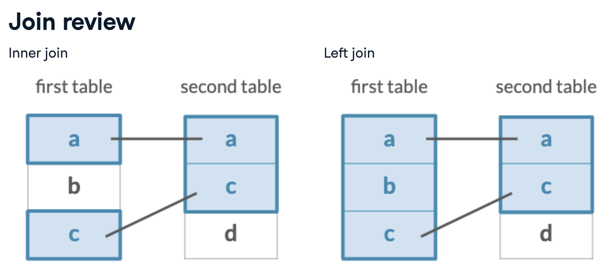

## 2.5 Exercícios

### 2.5.1 **Left joining two sets by part and color**

In the video, you learned how to left join two LEGO sets. Now you’ll practice your ability to do this looking at two new sets: the Millennium Falcon and Star Destroyer sets. We’ve created these for you and they have been preloaded for you:

```r
millennium_falcon <- inventory_parts_joined %>%
  filter(set_num == "7965-1")
```

```r
star_destroyer <- inventory_parts_joined %>%
  filter(set_num == "75190-1")
```

- Combine the `star_destroyer` and `millennium_falcon` tables with the suffixes `_falcon` and `_star_destroyer`.

```r
# Combine the star_destroyer and millennium_falcon tables
millennium_falcon %>%
    left_join(star_destroyer, by = c("part_num", "color_id"),
    suffix = c("_falcon", "_star_destroyer"))
```

```
## # A tibble: 263 x 8
##    set_num_falcon part_num color_id quantity_falcon is_spare_falcon
##    <chr>          <chr>       <dbl>           <dbl> <lgl>
##  1 7965-1         63868          71              62 FALSE
##  2 7965-1         3023            0              60 FALSE
##  3 7965-1         3021           72              46 FALSE
##  4 7965-1         2780            0              37 FALSE
##  5 7965-1         60478          72              36 FALSE
##  6 7965-1         6636           71              34 FALSE
##  7 7965-1         3009           71              28 FALSE
##  8 7965-1         3665           71              22 FALSE
##  9 7965-1         2412b          72              20 FALSE
## 10 7965-1         3010           71              19 FALSE
## # … with 253 more rows, and 3 more variables: set_num_star_destroyer <chr>,
## #   quantity_star_destroyer <dbl>, is_spare_star_destroyer <lgl>
```

- Usando esta tabela, e as variáveis `part_num` ou `color_id` podemos determinar a frequência que uma parte específica ou peça aperece nos conjuntos de Millenium Falcon e Star Destroyer.

### 2.5.2 **Left joining two sets by color**

In the videos and the last exercise, you joined two sets based on their part and color. What if you joined the datasets by color alone? As with the last exercise, the Millennium Falcon and Star Destroyer sets have been created and preloaded for you:

```
millennium_falcon <- inventory_parts_joined %>%
  filter(set_num == "7965-1")

star_destroyer <- inventory_parts_joined %>%
  filter(set_num == "75190-1")
```

- Sum the `quantity` column by `color_id` in the Millennium Falcon dataset.

```r
# Aggregate Millennium Falcon for the total quantity in each part
millennium_falcon_colors <- millennium_falcon %>%
  group_by(color_id) %>%
  summarize(total_quantity = sum(quantity))
millennium_falcon_colors
```

```
## # A tibble: 21 x 2
##    color_id total_quantity
##       <dbl>          <dbl>
##  1        0            201
##  2        1             15
##  3        4             17
##  4       14              3
##  5       15             15
##  6       19             95
##  7       28              3
##  8       33              5
##  9       36              1
## 10       41              6
## # … with 11 more rows
```

- Now, sum the `quantity` column by `color_id` in the Star Destroyer dataset.

```r
# Aggregate Star Destroyer for the total quantity in each part
star_destroyer_colors <- star_destroyer %>%
  group_by(color_id) %>%
  summarize(total_quantity = sum(quantity))
star_destroyer_colors
```

```
## # A tibble: 0 x 2
## # … with 2 variables: color_id <dbl>, total_quantity <dbl>
```

- Left join the two datasets, `millennium_falcon_colors` and `star_destroyer_colors`, using the `color_id` column and the `_falcon` and `_star_destroyer` suffixes.

```r
# Left join the Millennium Falcon colors to the Star Destroyer colors
millennium_falcon_colors %>%
  left_join(star_destroyer_colors, by = "color_id", suffix = c("_falcon", "_star_destroyer"))
```

```
## # A tibble: 21 x 3
##    color_id total_quantity_falcon total_quantity_star_destroyer
##       <dbl>                 <dbl>                         <dbl>
##  1        0                   201                            NA
##  2        1                    15                            NA
##  3        4                    17                            NA
##  4       14                     3                            NA
##  5       15                    15                            NA
##  6       19                    95                            NA
##  7       28                     3                            NA
##  8       33                     5                            NA
##  9       36                     1                            NA
## 10       41                     6                            NA
## # … with 11 more rows
```

### 2.5.3 **Finding an observation that doesn’t have a match**

Left joins are really great for testing your assumptions about a data set and ensuring your data has integrity.

For example, the `inventories` table has a `version` column, for when a LEGO kit gets some kind of change or upgrade. It would be fair to assume that all `sets` (which joins well with `inventories`) would have at least a version 1. But let’s test this assumption out in the following exercise.

- Use a `left_join` to join together `sets` and `inventory_version_1` using their common column.
- `filter` for where the `version` column is `NA` using `is.na`.

```r
inventory_version_1 <- inventories %>%
  filter(version == 1)

# Join versions to sets
sets %>%
  left_join(inventory_version_1, by = "set_num") %>%
  # Filter for where version is na
  filter(is.na(version))
```

```
## # A tibble: 4 x 7
##   set_num name                             year theme_id num_parts    id version
##   <chr>   <chr>                           <dbl>    <dbl>     <dbl> <dbl>   <dbl>
## 1 70904   Clayface Splat Attack            2017      484         0    NA      NA
## 2 70906   LEGO® Batman Movie - The Joker…  2017      484         0    NA      NA
## 3 75160   U-wing                           2017      158       107    NA      NA
## 4 76081-1 The Milano vs. The Abilisk       2017      483       456    NA      NA
```

- Parece que há casos em que um conjunto não tem uma versão original.

# 3 **The right-join verb**